# Spatial Phenological Patterns

Matthias Templ[^1]

Barbara Templ[^2]

2026-04-23

*Vignette 4 of 4 for the **pep725** R package. The most current version is available on [GitHub](https://github.com/matthias-da/pep725) and [CRAN](https://CRAN.R-project.org/package=pep725).*

## Introduction

Phenological timing varies systematically across space due to environmental gradients. Understanding these spatial patterns is fundamental to phenological research because it allows us to:

- **Scale observations**: Extrapolate from point measurements to landscapes
- **Predict impacts**: Forecast how climate change will shift phenological timing
- **Design networks**: Optimize monitoring station placement
- **Validate models**: Compare observed gradients with model predictions

This vignette covers spatial analysis and visualization functions in the `pep725` package, organized into four parts:

### What You’ll Learn

| Section | Key Concepts | Functions |
| --- | --- | --- |
| Part 1: Gradients | How phenology changes with altitude & latitude | `pheno_gradient()` |
| Part 2: Synchrony | Spatial coherence of phenological events | `pheno_synchrony()` |
| Part 3: Combined | Integrating gradient and synchrony results | `pheno_gradient()`, `pheno_synchrony()` |
| Part 4: Mapping | Visualizing station networks and patterns | `pheno_leaflet()`, `pheno_map()` |

### Prerequisites

This vignette assumes you have completed the “Getting Started” vignette and are familiar with:

- The basic structure of PEP725 data
- BBCH phenological phase codes
- Day of Year (DOY) as a timing metric

## Setup

```r
library(pep725)
library(data.table)
library(ggplot2)

# Download the synthetic dataset
pep <- pep_download()

# Overview of the data
cat("Stations:", length(unique(pep$s_id)), "\n")
```

```
#> Stations: 10927
```

```r
cat("Altitude range:", min(pep$alt, na.rm = TRUE), "-",
    max(pep$alt, na.rm = TRUE), "m\n")
```

```
#> Altitude range: 0 - 1933 m
```

```r
cat("Latitude range:", round(min(pep$lat, na.rm = TRUE), 2), "-",
    round(max(pep$lat, na.rm = TRUE), 2), "N\n")
```

```
#> Latitude range: 14.44 - 68.44 N
```

# Part 1: Phenological Gradients

## What are Phenological Gradients?

A **phenological gradient** describes systematic changes in the timing of biological events along an environmental axis. Such gradients reflect spatial variations in climatic conditions and are fundamental for understanding large-scale patterns in phenology. The two most important phenological gradients are associated with elevation and latitude:

### Altitudinal Gradient

With increasing elevation, air temperature generally decreases. As a result, phenological events tend to occur progressively later at higher altitudes. The rate at which phenological timing shifts with elevation is commonly referred to as the **phenological lapse rate**.

```
                     Mountain Profile
                          /\
                         /  \  <- Higher elevation = LATER phenology
                        /    \
                       /      \
         ____________/        \____________
              ^                     ^
         Earlier                  Earlier
        (lowland)                (lowland)
```

**Typical values**: In temperate regions of Europe, phenological phases are delayed by **2-4 days per 100 meters** of elevation gain. In practical terms: - A station at 500m elevation might observe flowering 10-20 days later than a lowland station. - High-elevation stations (2000m+) can exhibit delays of 40-80 days relative to lowland sites

### Latitudinal Gradient

Moving northward in the Northern Hemisphere is generally associated with cooler climatic conditions and changes in seasonal radiation regimes. Consequently, phenological events tend to occur later at higher latitudes.

**Typical values**: Across Europe, phenology is delayed by **2-5 days per degree of latitude** toward the north. For example: - The latitudinal difference between southern France (43°N) and northern Germany (54°N) is about 11 degrees - This corresponds to an expected difference of 22-55 days in phenology

### Why Study Gradients?

Understanding phenological gradients is valuable for several reasons:

1. **Scaling observations**: Gradients allow phenological timing to be extrapolated to locations without direct observations, based on elevation or latitude
2. **Validating models**: Phenological and crop models should reproduce observed spatial gradients
3. **Detecting change**: Temporal changes in the strength or shape of phenological gradients may signal climate-driven alterations in biological responses
4. **Understanding adaptation**: Systematic deviations from expected gradients may reveal local adaptation, genetic variation or the influence of site-specific factors.

## Altitudinal Gradient Analysis

Let’s calculate the elevational gradient for apple flowering:

```r
# Calculate elevational gradient for apple flowering
grad_alt <- pheno_gradient(
  pep = pep,
  variable = "alt",
  species = "Malus domestica",
  phase_id = 60,
  method = "robust"
)

print(grad_alt)
```

```
#> Phenological Gradient Analysis
#> --------------------------------------------------
#> Gradient variable: alt
#> Regression method: robust
#> Species: Malus domestica
#> Phase ID: 60
#> --------------------------------------------------
#>
#>    variable method    slope intercept  r_squared     rmse n_points
#>      <char> <char>    <num>     <num>      <num>    <num>    <int>
#> 1:      alt robust 1.211205  175.2758 0.03001843 26.46125     8307
#>                                                           interpretation
#>                                                                   <char>
#> 1: Phenology is 1.2 days later per 100m elevation increase (R-sq = 0.03)
#>
#> Interpretation:
#>    Phenology is 1.2 days later per 100m elevation increase (R-sq = 0.03)
```

### Understanding the Function Parameters

| Parameter | Purpose | Your Choice |
| --- | --- | --- |
| `pep` | Input data | Your phenological dataset |
| `variable` | Environmental gradient | `"alt"` for elevation, `"lat"` for latitude |
| `species` | Species to analyze | Must match exactly (e.g., “Malus domestica”) |
| `phase_id` | BBCH phase code | 60 = flowering |
| `method` | Regression method | `"robust"` recommended for phenological data |

### Interpreting the Results

The output contains several important metrics:

| Metric | What It Tells You | How to Interpret |
| --- | --- | --- |
| `slope` | Days delay per 100m elevation | The phenological lapse rate |
| `intercept` | Predicted DOY at 0m altitude | Theoretical baseline (extrapolation) |
| `r_squared` | Proportion of variance explained | How well elevation predicts phenology |
| `n_points` | Number of stations used | Sample size (affects reliability) |

**Key interpretation points:**

- **Positive slope**: Later phenology at higher elevations (expected)
- **Negative slope**: Earlier phenology at higher elevations (unusual - investigate!)
- **Slope magnitude**: Compare to literature values (2-4 days/100m typical)
- **R-squared**: Values > 0.3 indicate meaningful gradient; < 0.1 suggests weak control

## Latitudinal Gradient Analysis

The same function works for latitude gradients:

```r
# Calculate latitude gradient
grad_lat <- pheno_gradient(
  pep = pep,
  variable = "lat",
  species = "Malus domestica",
  phase_id = 60,
  method = "robust"
)

print(grad_lat)
```

```
#> Phenological Gradient Analysis
#> --------------------------------------------------
#> Gradient variable: lat
#> Regression method: robust
#> Species: Malus domestica
#> Phase ID: 60
#> --------------------------------------------------
#>
#>    variable method     slope intercept    r_squared     rmse n_points
#>      <char> <char>     <num>     <num>        <num>    <num>    <int>
#> 1:      lat robust 0.1380028  171.1092 0.0003639782 26.49628     8403
#>                                                            interpretation
#>                                                                    <char>
#> 1: Phenology is 0.1 days later per degree latitude increase (R-sq = 0.00)
#>
#> Interpretation:
#>    Phenology is 0.1 days later per degree latitude increase (R-sq = 0.00)
```

## Comparing Regression Methods

The `pheno_gradient()` function offers three regression methods. Choosing the right method matters because phenological data often contains outliers.

```r
# Robust regression (default) - handles outliers
grad_robust <- pheno_gradient(pep, variable = "alt",
                              species = "Malus domestica",
                              phase_id = 60, method = "robust")

# Ordinary least squares
grad_ols <- pheno_gradient(pep, variable = "alt",
                           species = "Malus domestica",
                           phase_id = 60, method = "ols")

cat("Robust slope:", round(grad_robust$summary$slope, 2), "days/100m\n")
```

```
#> Robust slope: 1.21 days/100m
```

```r
cat("OLS slope:", round(grad_ols$summary$slope, 2), "days/100m\n")
```

```
#> OLS slope: 0.22 days/100m
```

### Which Method Should You Use?

| Method | Strengths | Weaknesses | When to Use |
| --- | --- | --- | --- |
| `robust` | Resistant to outliers and leverage points | Slightly lower efficiency under ideal conditions (clean data) | Recommended **default choice** for phenological data |
| `ols` | Efficient when assumptions are met | Highly sensitive to outliers | Use after careful data screening |
| `quantile` | Models conditional medians or other quantiles | Less precise estimates (wider confidence intervals) | When focusing on median responses |

**Recommendation**: Start with `method = "robust"` for exploratory and applied analyses. Substantial differences between robust and OLS estimates often indicate influential observations and should prompt further inspection.

### Comparing Species: Grapevine Gradient

Different species may show different gradient strengths. Let’s compare apple with grapevine:

```r
# Calculate gradient for grapevine
vine_data <- pep[species == "Vitis vinifera"]

# Verify data exists before analysis
if (nrow(vine_data) > 0) {
  grad_vine <- pheno_gradient(
    pep = pep,
    variable = "alt",
    species = "Vitis vinifera",
    phase_id = 65,  # Full flowering
    method = "robust"
  )

  cat("Comparison of elevation gradients:\n")
  cat("Apple:     ", round(grad_robust$summary$slope, 2), "days/100m",
      "(R² =", round(grad_robust$summary$r_squared, 3), ")\n")
  cat("Grapevine: ", round(grad_vine$summary$slope, 2), "days/100m",
      "(R² =", round(grad_vine$summary$r_squared, 3), ")\n")
} else {
  cat("No grapevine data available for gradient analysis.\n")
}
```

```
#> Comparison of elevation gradients:
#> Apple:      1.21 days/100m (R² = 0.03 )
#> Grapevine:  0.05 days/100m (R² = 0 )
```

## Gradients by Region

Phenological gradients are not uniform across space. Their magnitude and shape can vary between regions due to: - Different climate zones - Local adaptation of species - Data quality differences

Estimating gradients separately for different regions:

```r
# Calculate gradient by country
grad_by_country <- pheno_gradient(
  pep = pep,
  variable = "alt",
  species = "Malus domestica",
  phase_id = 60,
  by = "country",
  method = "robust"
)

print(grad_by_country$summary)
```

```
#>              country      slope intercept    r_squared      rmse n_points
#>               <char>      <num>     <num>        <num>     <num>    <int>
#>  1:           France -0.5098724 125.16237 0.0008288199 77.910435      109
#>  2:          Austria  4.3428532 160.84490 0.0795285447 39.639290     1234
#>  3:           Norway         NA        NA           NA        NA        2
#>  4:    Germany-South  1.9631768 168.49517 0.1352181396 15.117422     1924
#>  5:          Czechia -8.8919479 242.31970 0.2560345827 21.314550       12
#>  6:          Hungary 65.0277647  75.32681 0.9348290289 45.149454        6
#>  7:            Spain -0.2565187 156.88922 0.0006775696 35.110133       36
#>  8:         Slovakia  2.4919661 144.08313 0.5354808286  8.420740       74
#>  9:    Germany-North  0.8295158 177.84818 0.0122156451 19.037512     4568
#> 10:      Switzerland  3.1563711  99.53822 0.6686215375 12.101512      168
#> 11:             <NA> 55.6580206 180.04261 0.2556121362 23.787673       36
#> 12:           Poland -3.9848006 185.69537 0.3800259994  8.128931       11
#> 13:       Montenegro  2.5621524 179.25280 0.5421907136  8.021958        5
```

[output cut: 72 more lines]

**What to look for:** - Consistency of slopes: Are slopes consistent across regions? Similar slope estimates across regions suggest a robust and generalizable gradient pattern. - Explained variance: Are R-squared values similar? (Comparable R-squared values indicate that the gradient explains phenological variability consistently across regions.) - Sample size adequacy: Do sample sizes support reliable estimates? (Reliable gradient estimates require sufficient data coverage; small sample sizes (e.g. n < 20) should be interpreted with caution.)

## Visualizing Gradients

Visualization plays a key role in interpreting and communicating phenological gradients, helping to assess linearity, uncertainty, and regional differences at a glance:

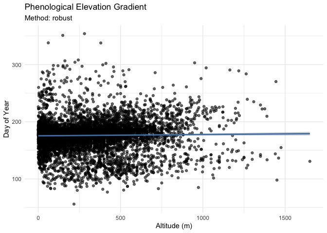

```r
# Plot the gradient relationship
if (!is.null(grad_alt$data) && nrow(grad_alt$data) > 2) {
  p <- plot(grad_alt)
  print(p)
}
```

**Reading the plot:** - Each point represents a station-level mean phenophase (averaged across years). - The fitted line shows the estimated relationship between phenophase and elevation. - Points deviating strongly from the line indicate locations where elevation alone explains phenology poorly. - Systematic clustering of residuals may point to regional influences or additional controlling factors.

## Expected Values and Troubleshooting

### Reference Values from Literature

The following table summarises phenological gradient values reported in the literature. These can serve as benchmarks when interpreting your own results:

| Gradient | Typical Range | Region | Sources |
| --- | --- | --- | --- |
| Altitude | 2–4 days/100m | Europe (temperate) | Pellerin et al. (2012); Vitasse et al. (2009); Ziello et al. (2009) |
| Altitude | 1–3 days/100m | Europe (warm / low elevation) | Vitasse et al. (2009); Ziello et al. (2009) |
| Latitude | 2–4 days/degree | Europe | Rötzer & Chmielewski (2001) |
| Latitude | 3–5 days/degree | North America | Hopkins (1918); Richardson et al. (2019) |

**Notes:**

**Key references:**

- Pellerin, M. et al. (2012). Spring tree phenology in the Alps. *European Journal of Forest Research*, 131, 1957–1965. [doi:10.1007/s10342-012-0646-1](https://doi.org/10.1007/s10342-012-0646-1)
- Vitasse, Y. et al. (2009). Leaf phenology sensitivity to temperature in European trees. *Agricultural and Forest Meteorology*, 149, 735–744. [doi:10.1016/j.agrformet.2008.10.019](https://doi.org/10.1016/j.agrformet.2008.10.019)
- Ziello, C. et al. (2009). Influence of altitude on phenology of selected plant species in the Alpine region. *Climate Research*, 39, 227–234. [doi:10.3354/cr00822](https://doi.org/10.3354/cr00822)
- Rötzer, T. & Chmielewski, F.-M. (2001). Phenological maps of Europe. *Climate Research*, 18, 249–257. [doi:10.3354/cr018249](https://doi.org/10.3354/cr018249)
- Richardson, A.D. et al. (2019). Testing Hopkins’ Bioclimatic Law with PhenoCam data. *Applications in Plant Sciences*, 7, e01228. [doi:10.1002/aps3.1228](https://doi.org/10.1002/aps3.1228)
- Chen, L. et al. (2018). Spring phenology at different altitudes is becoming more uniform under global warming in Europe. *Global Change Biology*, 24, 3969–3975. [doi:10.1111/gcb.14288](https://doi.org/10.1111/gcb.14288)

### When Your Results Differ from Expected

| Observation | Possible Causes | What to Do |
| --- | --- | --- |
| Slope too steep (>5 days/100m) | Outliers, microclimate effects | Check for data errors, use robust method |
| Slope too shallow (<1 day/100m) | Limited elevation range, species adaptation | Expand geographic scope |
| Negative slope | Data errors, southern aspect effects | Investigate unusual observations |
| Very low R² | Other factors dominate (precipitation, soil) | Consider multiple regression |

# Part 2: Phenological Synchrony

## What is Phenological Synchrony?

**Phenological synchrony** describes the degree to which phenological events occur at similar times across different locations within a region during a given period. It addresses the question: Do stations experience the same phenological phase at roughly the same time?

### Visualizing Synchrony Concepts

```
High Synchrony (SD = 5 days)        Low Synchrony (SD = 25 days)

Station A: ●────────●               Station A: ●────────●
Station B:  ●────────●              Station B:          ●────────●
Station C: ●────────●               Station C:   ●────────●
Station D:  ●────────●              Station D:              ●────────●
           ▲                                    ▲
           All stations flower                  Stations flower at
           within ~10 day window                very different times
```

### Why Study Synchrony?

1. **Ecosystem coherence**: High synchrony suggests strong regional climate control, whereas low synchrony indicates a greater influence of local factors.
2. **Monitoring network design**: When synchrony is high, fewer stations may be sufficient to characterize a region; low synchrony implies the need for denser observation networks.
3. **Detection of change**: Temporal changes in synchrony can indicate shifts in climate variability, increasing spatial heterogeneity, or emerging local adaptations.
4. **Ecological consequences**: Synchrony influences ecological interactions such as pollination, pest dynamics, and trophic mismatch.

## Calculating Synchrony

The `pheno_synchrony()` function calculates several metrics to quantify spatial variability:

```r
# Calculate synchrony by country and year
sync <- pheno_synchrony(
  pep = pep,
  species = "Malus domestica",
  phase_id = 60,
  by = c("country", "year"),
  min_stations = 3
)

print(sync)
```

```
#> Phenological Synchrony Analysis
#> --------------------------------------------------
#> Species: Malus domestica
#> Phase ID: 60
#> Grouping: country, year
#> Min stations required: 3
#> --------------------------------------------------
#>
#> Overall Statistics:
#>   Total groups: 1175 (valid: 709)
#>   Mean SD across stations: 9.6 days
#>   Mean CV: 8.1%
#>   Mean stations per group: 241.5
#>
#> Synchrony Data:
#>     country  year n_stations mean_doy sd_doy cv_pct range_doy iqr_doy min_doy
#>      <char> <int>      <int>    <num>  <num>  <num>     <int>   <num>   <int>
#>  1:    <NA>  1951          9    142.8   8.03   5.63        27     6.5     129
#>  2:    <NA>  1952          7    136.6   9.02   6.60        23    10.8     122
#>  3:    <NA>  1953          5    136.0   6.28   4.62        13    12.0     130
#>  4:    <NA>  1954          9    140.4   7.17   5.10        23     9.5     131
#>  5:    <NA>  1955         12    141.5   9.59   6.78        28    15.5     126
#>  6:    <NA>  1956          9    141.6  10.97   7.75        34     9.0     121
#>  7:    <NA>  1957         11    136.6   8.45   6.18        25    13.8     120
#>  8:    <NA>  1958         12    133.7   9.57   7.16        31    15.2     115
#>  9:    <NA>  1959         14    129.9  13.46  10.37        54    14.0     106
#> 10:    <NA>  1960         13    135.2   9.45   6.99        27    14.0     122
#>     max_doy
#>       <int>
#>  1:     156
#>  2:     145
#>  3:     143
#>  4:     154
#>  5:     154
#>  6:     155
#>  7:     145
#>  8:     146
#>  9:     160
#> 10:     149
#>
```

[output cut: 34 more lines]

```
#> 11:  0.6400 decreasing synchrony       FALSE
#> 12:  0.2425 decreasing synchrony       FALSE
#> 13:  0.0000 decreasing synchrony        TRUE
#> 14:  0.0343 decreasing synchrony        TRUE
#> 15:  0.0005 increasing synchrony        TRUE
#> 16:      NA                 <NA>          NA
#> 17:  0.0260 increasing synchrony        TRUE
#>
#> Significant trends detected:
#>   Germany-North: increasing synchrony (p = 0.0000)
#>   Germany-South: increasing synchrony (p = 0.0000)
#>   Slovakia: decreasing synchrony (p = 0.0000)
#>   Slovenia: decreasing synchrony (p = 0.0343)
#>   Spain: increasing synchrony (p = 0.0005)
#>   Switzerland: increasing synchrony (p = 0.0260)
```

### Understanding the Parameters

| Parameter | Purpose | Typical Values |
| --- | --- | --- |
| `pep` | Input dataset | Phenological dataset prepared with `pep725` |
| `species` | Species to analyze | Single species for clear interpretation |
| `phase_id` | Phenophase coded by the BBCH-scale (Meier, 2018) | e.g. 60 (flowering), 65 (full flowering) |
| `by` | Grouping variables | `c("country", "year")` for regional, year-specific analysis |
| `min_stations` | Minimum number of stations per group | 3-5 as a lower bound; 10+ recommended for robust estimates |
| `compute_trend` | Estimate temporal trends in synchrony | TRUE (default) when assessing changes over time |

## Understanding Synchrony Metrics

Different synchrony metrics capture complementary aspects of spatial variability. Selecting an appropriate metric depends on the analysis goal and data characteristics:

| Metric | Formula | Interpretation | When to Use |
| --- | --- | --- | --- |
| `sd_doy` | Standard deviation of day-of-year | Absolute variability in days | Comparing synchrony across phases or regions |
| `cv_pct` | (SD/mean) × 100 | Relative variability | Comparing phases with different mean timing |
| `range_doy` | Maximum minus minimum doy | Total observed spread | Assessing extreme differences |
| `iqr_doy` | 75th - 25th percentile | Robust measure of spread | Preferred when outliers are present |

**Interpretation guide:**

The following table provides a rule-of-thumb interpretation of synchrony based on the standard deviation of phenological timing across stations. Thresholds are indicative and should be interpreted in relation to species, phenophase, and spatial extent:

| SD Value | Interpretation |
| --- | --- |
| < 5 days | Very high synchrony; stations behave very similarly |
| 5-10 days | Moderate synchrony; regional pattern dominates |
| 10-20 days | Low synchrony; local variability is substantial |
| > 20 days | Very low synchrony; local factors dominate |

```r
summary(sync)
```

```
#> Phenological Synchrony Summary
#> ==================================================
#>
#> Species: Malus domestica
#> Phase ID: 60
#>
#> Groups analyzed: 1175
#> Groups with sufficient stations: 709 (60.3%)
#>
#> Synchrony Statistics (across all valid groups):
#>   Mean SD: 9.6 days
#>   Median SD: 9.4 days
#>   Mean CV: 8.1%
#>
#> SD Distribution:
#>   Min: 1.7 days
#>   25th percentile: 7.8 days
#>   Median: 9.4 days
#>   75th percentile: 11.5 days
#>   Max: 26.9 days
#>
#> Trend Summary:
#>   Regions with significant trends: 6 of 17
#>   Increasing synchrony: 4
#>   Decreasing synchrony: 2
```

## Temporal Trends in Synchrony

An important question in phenological analysis is whether spatial synchrony changes over time.

- **Decreasing synchrony**: means growing spatial heterogeneity, for example due to more variable weather or diverging local conditions.
- **Increasing synchrony**: suggests stronger regional coherence, potentially driven by a common climate signal overriding local factors

```r
# Check if trend analysis was performed
if (!is.null(sync$trend) && nrow(sync$trend) > 0) {
  cat("Trend Analysis Results:\n")
  print(sync$trend)

  # Interpret significant trends
  sig_trends <- sync$trend[!is.na(significant) & significant == TRUE]
  if (nrow(sig_trends) > 0) {
    cat("\nSignificant trends detected:\n")
    print(sig_trends[, .(country, slope, direction, p_value)])
  }
}
```

```
#> Trend Analysis Results:
#> Index: <significant>
#>              country n_years year_min year_max   slope intercept r_squared
#>               <char>   <int>    <int>    <int>   <num>     <num>     <num>
#>  1:             <NA>      73     1951     2023 -0.0201     48.06     0.036
#>  2:          Austria      87     1926     2025  0.0097     -7.34     0.034
#>  3: Bosnia and Herz.      30     1971     2024 -0.0708    153.54     0.069
#>  4:          Croatia      52     1967     2020 -0.0287     66.69     0.010
#>  5:          Czechia      25     1951     1980  0.1452   -276.73     0.059
#>  6:    Germany-North      73     1951     2023 -0.0289     66.53     0.463
#>  7:    Germany-South      73     1951     2023 -0.0457    100.76     0.633
#>  8:          Hungary       6     1969     2000      NA        NA        NA
#>  9:            Italy      15     1989     2003 -0.3111    630.23     0.411
#> 10:        Lithuania      45     1960     2004  0.0263    -45.71     0.051
#> 11:       Montenegro      36     1952     2021  0.0198    -28.97     0.009
```

[output cut: 35 more lines]

### Interpreting Trend Results

| Trend Direction | Interpretation | Ecological meaning |
| --- | --- | --- |
| Decreasing SD | Increasing synchrony | Phenological timing becoming more spatially coherent |
| Increasing SD | Decreasing synchrony | Growing spatial variability among stations |
| No trend | Stable synchrony | Persistent spatial patterns over time |

**Cautions with trend interpretation:** - Changes in the observation network (e.g. stations added or removed) can introduce artificial trends. - Reliable trend detection typically requires at least 15–20 years of data. - Statistical significance should be interpreted alongside ecological relevance and effect size.

## Visualizing Synchrony Over Time

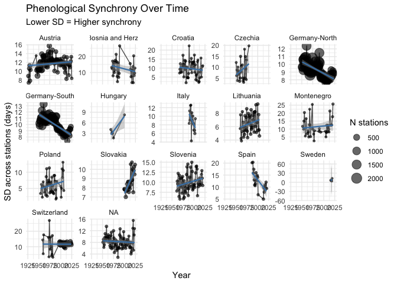

```r
# Plot synchrony time series
if (nrow(sync$data[!is.na(sd_doy)]) > 5) {
  p <- plot(sync)
  print(p)
}
```

**Reading the plot:** - Y-axis shows the synchrony metric (typically the SD of timing) - The fitted trend line indicates long-term change - Scatter around trend reflects year-to-year variability in synchrony

## Synchrony Without Trend Analysis

For exploratory analyses or descriptive summaries, synchrony can be calculated without estimating temporal trends:

```r
sync_simple <- pheno_synchrony(
  pep = pep,
  species = "Malus domestica",
  phase_id = 60,
  by = c("country", "year"),
  min_stations = 3,
  compute_trend = FALSE
)

# Just the synchrony data
head(sync_simple$data)
```

```
#>    country  year n_stations mean_doy sd_doy cv_pct range_doy iqr_doy min_doy
#>     <char> <int>      <int>    <num>  <num>  <num>     <int>   <num>   <int>
#> 1:    <NA>  1951          9    142.8   8.03   5.63        27     6.5     129
#> 2:    <NA>  1952          7    136.6   9.02   6.60        23    10.8     122
#> 3:    <NA>  1953          5    136.0   6.28   4.62        13    12.0     130
#> 4:    <NA>  1954          9    140.4   7.17   5.10        23     9.5     131
#> 5:    <NA>  1955         12    141.5   9.59   6.78        28    15.5     126
#> 6:    <NA>  1956          9    141.6  10.97   7.75        34     9.0     121
#>    max_doy
#>      <int>
#> 1:     156
#> 2:     145
#> 3:     143
#> 4:     154
#> 5:     154
#> 6:     155
```

This approach is useful for rapid assessment or when time series length is insufficient for robust trend estimation.

### Comparing Synchrony: Grapevine vs. Apple

Different species may show different synchrony levels due to their biology:

```r
# Calculate synchrony for grapevine
vine_check <- pep[species == "Vitis vinifera" & phase_id == 65]

if (nrow(vine_check) > 0) {
  sync_vine <- pheno_synchrony(
    pep = pep,
    species = "Vitis vinifera",
    phase_id = 65,
    by = c("country", "year"),
    min_stations = 3,
    compute_trend = FALSE
  )

  cat("Synchrony comparison (mean SD across years):\n")
  cat("Apple (flowering):    ", round(sync$overall$mean_sd_doy, 1), "days\n")
  cat("Grapevine (flowering):", round(sync_vine$overall$mean_sd_doy, 1), "days\n")
} else {
  cat("Insufficient grapevine data for synchrony comparison.\n")
}
```

```
#> Synchrony comparison (mean SD across years):
#> Apple (flowering):     9.6 days
#> Grapevine (flowering): 11.5 days
```

# Part 3: Combining Gradient and Synchrony Analysis

A comprehensive spatial phenological analysis typically combines gradient and synchrony approaches. While each addresses a different aspect of spatial structure, together they provide a more complete picture of how phenology varies across landscapes.

| Analysis | Question Answered |
| --- | --- |
| Gradient | How does MEAN phenological timing change across space? |
| Synchrony | How VARIABLE is phenology within regions? |

Gradients describe systematic spatial shifts (e.g. with elevation or latitude), whereas synchrony captures the degree of spatial coherence around these shifts.

```r
# 1. Understand elevation gradient
gradient <- pheno_gradient(
  pep, variable = "alt",
  species = "Malus domestica",
  phase_id = 60
)

cat("Elevation Gradient Analysis:\n")
```

```
#> Elevation Gradient Analysis:
```

```r
cat("  Slope:", round(gradient$summary$slope, 2), "days/100m\n")
```

```
#>   Slope: 1.21 days/100m
```

```r
cat("  R-squared:", round(gradient$summary$r_squared, 3), "\n\n")
```

```
#>   R-squared: 0.03
```

```r
# 2. Assess spatial synchrony
synchrony <- pheno_synchrony(
  pep,
  species = "Malus domestica",
  phase_id = 60,
  min_stations = 3
)

cat("Synchrony Analysis:\n")
```

```
#> Synchrony Analysis:
```

```r
cat("  Mean SD across stations:", round(synchrony$overall$mean_sd_doy, 1), "days\n")
```

```
#>   Mean SD across stations: 9.6 days
```

```r
cat("  Mean CV:", round(synchrony$overall$mean_cv_pct, 1), "%\n")
```

```
#>   Mean CV: 8.1 %
```

The two analyses answer complementary questions: the gradient quantifies the direction and strength of spatial change, while synchrony indicates how tightly phenological timing aligns around that spatial pattern.

## Interpreting Combined Results

Interpreting gradients and synchrony together helps to identify the dominant controls on phenology within a region:

| Gradient | Synchrony | Interpretation | Example |
| --- | --- | --- | --- |
| Strong | High | Clear environmental control with uniform response | Continental climate regions |
| Strong | Low | Environmental control with strong local variation | Mountain regions with microclimates |
| Weak | High | Broad regional climate signal dominates | Coastal or maritime regions |
| Weak | Low | Phenology shaped by complex local factors | Highly fragmented landscapes |

This combined perspective is particularly useful for comparing regions, diagnosing model performance, and identifying where local processes may override large-scale climatic drivers.

# Part 4: Mapping Phenological Patterns

Spatial visualization is a critical component of phenological analysis. Before formal modeling, maps help to assess station coverage, identify spatial gaps, and explore geographic patterns in phenological timing. The `pep725` package provides two mapping functions:

| Function | Type | Best suited for |
| --- | --- | --- |
| `pheno_leaflet()` | Interactive | Data exploration and station selection |
| `pheno_map()` | Static | Analysis summaries and publication-quality figures |

## Interactive Maps with pheno_leaflet()

The `pheno_leaflet()` function launches an interactive Shiny-based map for exploring phenological station networks. It is particularly useful during the early stages of analysis for:

- exploring spatial coverage and station density,
- interactively selecting subsets of stations,
- understanding geographic context before aggregation or modeling.

```r
# Launch interactive map (opens in viewer)
# Draw rectangles or polygons to select stations
selected_stations <- pheno_leaflet(pep, label_col = "species")

# The function returns a data.frame of selected stations
print(selected_stations)
```

[output not shown]

### Features of pheno_leaflet()

The interactive map supports multiple selection and inspection tools:

| Feature | Purpose |
| --- | --- |
| **Click selection** | Select individual stations |
| **Rectangle selection** | Select rectangular geographic areas using the rectangle tool from the toolbar |
| **Polygon selection** | Define custom shapes to select irregular regions |
| **Hover labels** | Move mouse over points to inspect station metadata |
| **Done button** | Click “Done” to finalize and return selected stations |

The function returns a `data.frame` containing all selected stations with their coordinates and metadata, which can then be directly reused in subsequent analysis.

### Best Practices for Interactive Mapping

**Tip**: For large datasets, filtering before mapping substantially improves performance.

```r
# Filter to a specific species for faster loading (recommended)
apple <- pep[species == "Malus domestica"]
selected <- pheno_leaflet(apple, label_col = "s_id")

# Use selected stations for focused analysis
apple_subset <- apple[s_id %in% selected$s_id]
```

**Why filter first?** The full PEP725 dataset contains millions of observations. Rendering all these points in an interactive map can take long. Restricting the dataset to a species or region of interest results in faster loading and smoother interaction.

## Static Maps with pheno_map()

The `pheno_map()` function creates static maps suitable for reporting and publication. Two background options are supported:

| `background` | Description | API Key Required? |
| --- | --- | --- |
| `"none"` | Country borders from Natural Earth | No |
| `"google"` | Google Maps satellite/terrain imagery | Yes |

For most applications, the `background = "none"` option is recommended because it: - requires no external services (API key setup), - works reliably in package vignettes, - produces reproducible, publication-ready maps

### Basic Station Maps

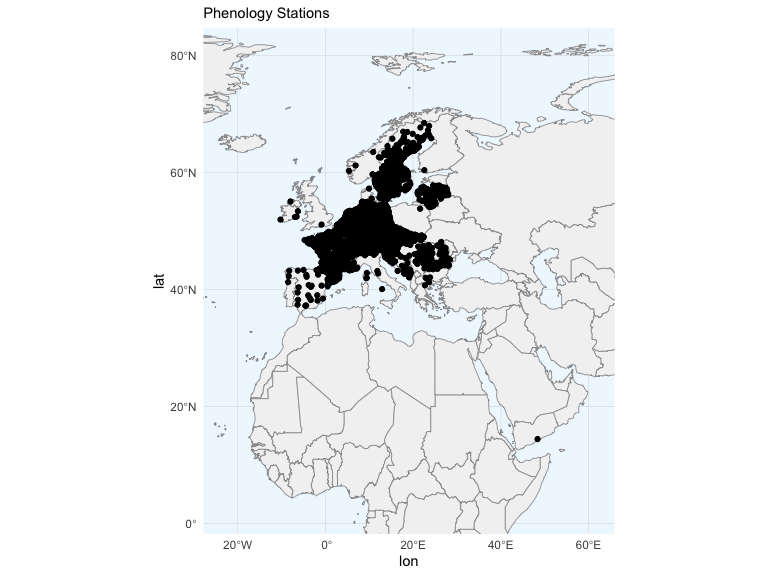

```r
# Basic station map with country borders (no API key needed)
pheno_map(pep, background = "none", color_by = "none", point_size = 1.5)
```

This view is useful for assessing overall network coverage and geographic gaps.

### Coloring by Data Attributes

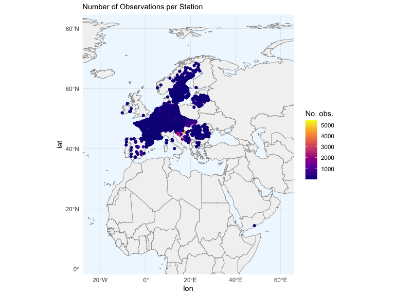

```r
# Color stations by number of observations
pheno_map(pep, background = "none", color_by = "n_obs", point_size = 1.5)
```

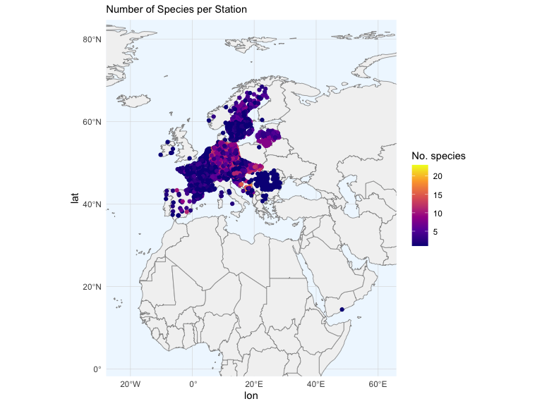

```r
# Color by species diversity at each station
pheno_map(pep, background = "none", color_by = "n_species", point_size = 1.5)
```

### Using Google Maps Background

For satellite imagery (requires API key from Google Cloud Console):

```r
# Register your API key first
ggmap::register_google(key = "your_api_key_here")

# Then use background = "google"
pheno_map(pep, background = "google", color_by = "n_obs", zoom = 5)

# Regional focus with Google Maps
pheno_map(
  pep,
  background = "google",
  location = c(lon = 8.2, lat = 46.8),
  zoom = 7,
  color_by = "n_obs"
)
```

These maps help identify well-monitored stations and multi-species observation sites.